# Markov Chains Demo

February 14, 2020 updated 2020-09-30

## Nice Markov Chains

Three properties:

- Irreducibility
- Aperiodicity
- Positive Recurrence

## Irreducibility

No matter where it starts, the chain has to reach any other state in a finite number of iterations with positive probability.

## Apriodicity

- **sojourn times**: time to get back to \(i\), starting from state \(i\).
- For all states \(i\), the set of all possible **sojourn times** can have no divisior bigger than \(1\). [This is a technical condition, periodic chains are also nice, but aperioic chains are nicer !]
- Easiest example: hours of a clock.

## Positive Recurrence

1. For all states \(i\), if the process starts at \(i\), it will come back to \(i\) with probability 1, and
2. The expected length of waiting time till the first return to \(i\) is finite.

Fact: Random walk on 1-D and 2-D are recurrent, but on 3-D is transient.

## Examples of Markov Chain (1)

- Discrete-time Markov chain with discrete-state space.
- Imagine a particle that moves around on the integers \(\{\ldots, -2,-1, 0, 1, 2, \ldots \}\), starting at 0.
- Wherever it is at time \(t\), say at integer \(i\), it tosses a (three-sided) coin and moves to \(i-1\) with probability \(p_1\), stays at \(i\) with probability \(p_2\), and moves to \(i + 1\) with probability \(p_3\), for some \(p_1, p_2, p_3\) with \(p_1 + p_2 + p_3 = 1\).
- These are called transition probabilities.
- This is called a random walk and it’s clearly a Markov Chain.

## Unbounded random walk

- The Unbounded random walk is irreducible and aperiodic, but it may not be positive recurrent.
- It is true that it has positive probability of returning to its starting point, but because \(S\) is unbounded, this probability may not be 1, and on average you have to wait forever for it to return.
- We can fix this by **bounding** \(S\) and keeping the same transition probabilities except for rejecting moves outside the state space, the chain now has all the nice properties.

## Bounded Random Walk

Simulate a bounded random walk with user-specified bound \(K\), transition probabilities \(p\), number of simulations `n.sim` and a seed for random number generator `seed’ .

```r
move <- function(k,p,theta){

  ## k: bound
  ## p: transition probability
  ## theta: sample path

  repeat{
    increment <- sample(x = c(-1,0,1),size=1,prob=p)
    theta.next <-  theta + increment
    if(abs(theta.next)<=k){
      return(theta.next)
      break
    }
  }
}
```

## Bounded Random Walk

- Here is the code for simulating random walk based on the function `move`.

```r
rw.sim <- function(k,p,theta.start,n.sim,seed){

  set.seed(seed)
  theta <- rep(0,n.sim + 1)
  theta[1] <- theta.start
  for(i in 1:n.sim){
    theta[i+1] <- move(k,p,theta[i])
  }
  return(theta)
}
```

## Bounded Random Walk

```r
p <- c(1,1,1)/3 # Uniform probability
k <- 5 # Bounded random walk
theta.start <- 0 # Starting at origin

seed<- c(7656,87678) #try two different seeds
```

- Try \(n = 10\)

```r
theta1 <- rw.sim(k,p,theta.start,10,seed)
table(theta1)
```

```
## theta1
## -1  0  1
##  1  8  2
```

## Larger \(n\)

```r
theta2<- rw.sim(k,p,theta.start,500,seed); table(theta2)
```

```
## theta2
## -5 -4 -3 -2 -1  0  1  2  3  4  5
## 28 45 43 42 70 49 33 61 63 42 25
```

```r
theta3 <- rw.sim(k,p,theta.start,1e3,seed); table(theta3)
```

```
## theta3
##  -5  -4  -3  -2  -1   0   1   2   3   4   5
##  72 132 103 123 135  87  51  85  93  76  44
```

```r
theta4 <- rw.sim(k,p,theta.start,1e4,seed); table(theta4)
```

```
## theta4
##   -5   -4   -3   -2   -1    0    1    2    3    4    5
##  657 1038  943  951  951  935  950  953 1000 1008  615
```

## Convergence

- You can see that the distribution of where the chain has visited is converging to something close to uniform on \(\{ -5, -4, . .. , 4, 5\}\), except for the effects of the boundaries.
- Letting \(q_1\) denote the limiting probability of being in one of the 9 non-boundary states \((-4, -3, .. . , 3, 4)\) and \(q_2\) be the long-run probability of being in one of the 2 boundary states \((-5, 5)\), on grounds of symmetry you can guess that \(q_1\) and \(q_2\) should satisfy:

\[ 9q_1 + 2q_2 = 1, \; \text{and } q_1 = \frac{3}{2}q_2 \]

## Convergence

The solution to the above equations are: \[ (q_1, q_2) = (\frac{3}{31},\frac{2}{31}) = (0.096774, 0.064516) \] - This matches with the relative frequencies:

```r
theta4 <- rw.sim(k,p,theta.start,1e5,seed); table(theta4)
```

```
## theta4
##    -5    -4    -3    -2    -1     0     1     2     3     4     5
##  6426  9718  9595  9555  9287  9322  9482  9738  9949 10088  6841
```

## Empirical Estimates

- We can empirically estimate these probabilities:

```r
(q_2<- sum(table(theta4)[c(1,11)])/(2*1e5))
```

```
## [1] 0.066335
```

```r
(q_1<- sum(table(theta4)[-c(1,11)])/(9*1e5))
```

```
## [1] 0.09637111
```

- This is the limiting (or Stationary) distribution.
- Also, note that the limiting distribution does not depend on the initial values of the chain.

## Try at home

- Try different choices of the transition probabilities \((p_1, p_2, p_3)\) and see if your empirical estimates are matching with the theroetical stationary distribution.

## Example 2 : AR process

- Discrete-time Markov chain with continuous-state space:
- \(\theta^*_{t+1} \sim N(0.5 \times \theta^*_{t}, 1.0)\).
- This is called a first order auto-regressive process with lag-1 auto-correlation \(0.5\).
- This is a Markov Chain, and it satisfies all three “nice” properties.

## R code for simulating AR process

```r
ar1simulate <- function(len, init){
  x = rep(0,len)
  x[1] = init
  for(t in 2:length(x)){
    x[t] = 0.5*x[t-1]+rnorm(1)
  }
  return(x)
}
```

## Plot the AR process

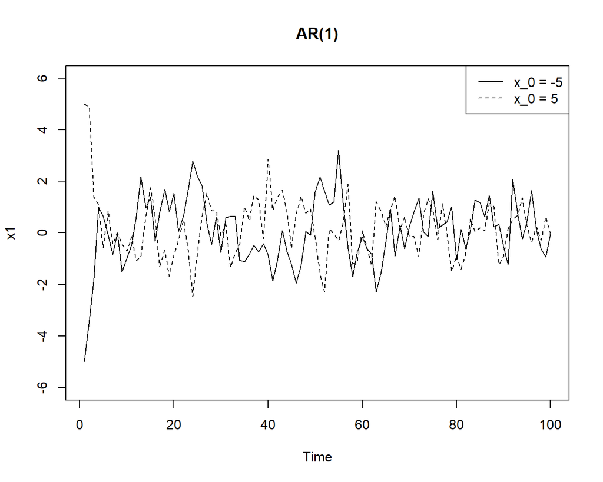

## Try at home

- Prove that the stationary distribution of the AR process is:

\[ \theta^{(t)} \mid \theta^{(0)} \sim N(0, 1.33) \text{ as } t \to \infty \]